# Modulo 3: Data Management & Data Digital

Preparar datos de Facebook por país

Leandro Gutierrez

20/07/2024

## Descripción de la tarea

El objetivo de esta actividad consiste en realizar la preparación de datos inicial para analizar, en fases posteriores, las métricas y mejorar la calidad de los datos.

Los datos a preparar están contenidos en la tabla FACEBOOK_2010_2018_RAW.csv.

- Pais: nombre del país. Un mismo país puede variar su nombre según el indicador.
- Valor: Valores numéricos. Puede presentar formatos distintos, según el indicador.
- Indicador: Formato: Año | indicador:
- Año: 2010 o 2018.
- Indicador:
  - Facebook: número de usuarios de Facebook en todo el país.
  - Internet_por: porcentaje de población usuaria de internet.
- poblacion: total de población por país.

## Tareas que debes realizar:

1. Carga los datos del fichero en un data frame. ¿Por qué no es un conjunto de datos ordenado?
2. Separa el año y el “indicador” en dos columnas separadas: anyo, variable. Presenta la tabla de las frecuencias de cada nueva variable.
3. Codifica el nombre de los países en una nueva columna “pais_r” donde, al analizar la tabla de frecuencias cada país, tenga frecuencia 6.
4. Pivota la tabla a formato wide de forma que cada variable tenga su propia columna y cada país dos filas (una para cada año). Comenta la estructura de la tabla (glimpse).
5. Transforma las tres variables (Facebook, Internet_por, poblacion) a formato numérico en tres variables nuevas con el sufijo “_num”. Aplica antes la/s transformación/es de las variables de texto que creas conveniente. Presenta el summary de las variables nuevas.
6. Analiza y comenta si observas alguna otra inconsistencia en los datos preparados.
7. Escribe cuatro líneas explicando (para un lector no técnico) la penetración de Facebook y de Internet en España.

# Solución

## Apartado 1

### Carga de los datos

```r
# leemos los datos utilizando `read.csv`
data <- read.csv(url("https://raw.githubusercontent.com/griu/mbdds_fc20/master/gestion_datos/www/Facebook_10_18_raw.csv"),
                sep = ";")

# creamos un dataframe tibble a partir de los datos
df <- as_tibble(data)
```

### Visualización

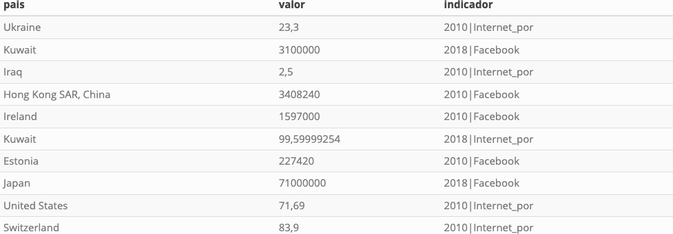

img-1

### Respuesta

No es un conjunto de datos ordenado puesto que cada fila no representa el total características de una observación. Podemos observar que dentro de la variable `indicador`, estan presentes las variables `anio` y `variable` apiñadas. Para lograr un conjunto de datos ordenados: - Debemos splitear la columna `indicador` en dos nuevas, una representando `anio` y la otra `variable`. - Luego convertir cada valor posible de la nueva columna `variable` a una columna por si misma.

## Apartado 2

Para lograr separar los valores del campo `indicador` utilizaremos la librería `dlpyr` y la función `separate`, teniendo en cuenta que el caracter que se usa de concatenación en este caso fué `|` (pipe).

```r
# creamos un dataframe auxiliar con el split solicitado
df_aux <- df %>%
    separate(indicador, into = c("anyo", "variable"), sep = "\\|")
```

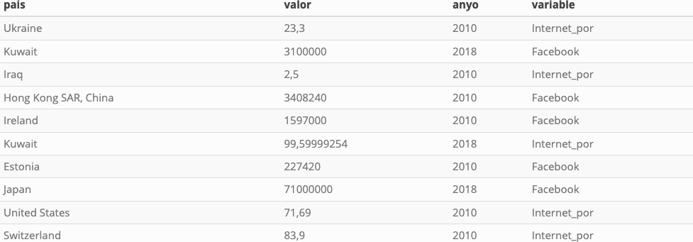

img-2

Veamos los valores que toman estas nuevas variables y sus respectivas frecuencias:

#### Anyo

Frecuencias de la columna `anyo`:

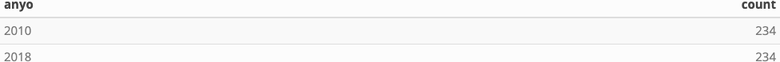

img-3

#### Variable

Frecuencias de la columna `variable`:

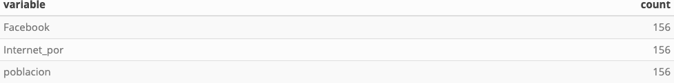

img-4

Podemos apreciar que ambas frecuencias acumuladas dan **468** elementos.

## Apartado 3

Agregaremos nuestro dataset por pais y aplicaremos una función `count()` para determinar la cantidad de ocurrencias. Vemos que algunos paises no cumplen la condición de frecuencia igual 6. Por lo tanto, debemos investigar y determinar cuales y por que no cumplen la condición esperada:

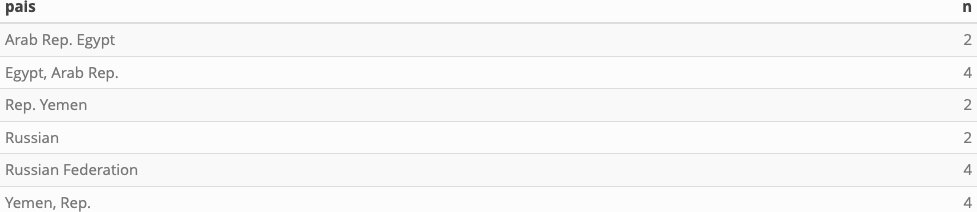

img-5

Podemos asumir que un mapeo no homogeneo de las claves produjeron la inconsistencia en el conteo. Además observando podemos intuir el problema:
$$\begin{aligned}
Arab\ Rep.\ Egypt &= Egypt,\ Arab Rep. \\
Rep.\ Yemen &= Yemen,\ Rep. \\
Russian &= Russian\ Federation
\end{aligned}$$

Debemos codificar de manera que nuestras claves estén etiquetadas de manera uniforme y cumplir con los requerimientos iniciales. Para ello crearemos una columna auxiliar donde estará el nuevo valor codificado de la variable `pais`

```r
# declaramos nuestro funcion de mapeo
mapear <- function(pais) {
    if (pais == 'Egypt, Arab Rep.'){
        return('Arab Rep. Egypt')
    } else if(pais == 'Yemen, Rep.'){
        return('Rep. Yemen')
    }else if(pais == 'Russian'){
        return('Russian Federation')
    }
    return(pais)
}

# creamos una nueva columna con el resultado de aplicar la funcion `mapear` a cada elemento de la columna `pais`
df_aux$pais_r <- sapply(as.vector(df_aux$pais), mapear)
```

Observamos que ahora todos nuestros registros agrupados por `pais_r` poseen 6 elementos, veamos algunas frecuencias:

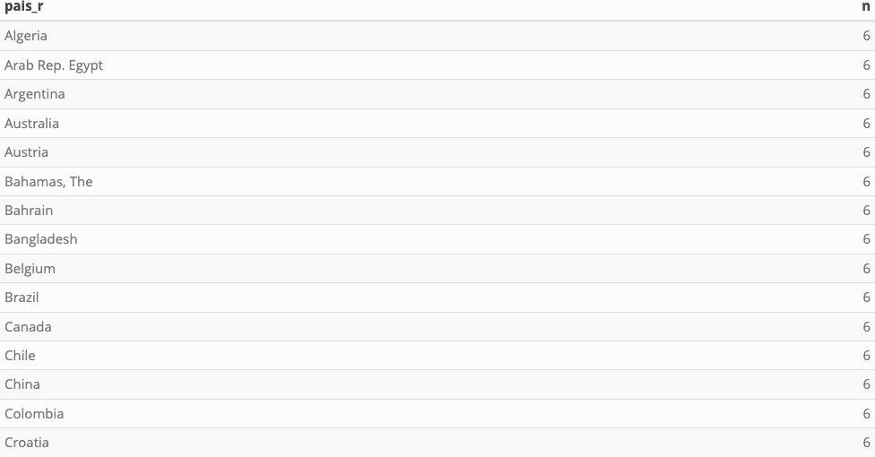

img-7

Observamos que entre los datos devueltos está el valor `Arab Rep. Egypt`, uno de los cuales fue limpiado y unificado mediante nuestra función `mapear`, podemos decir que cumplimos el objetivo de homogeneizarr los valores de nuestra variable `pais_r`.

## Apartado 4

Primero veamos los datos ordenados por la nueva variable `pais_r`

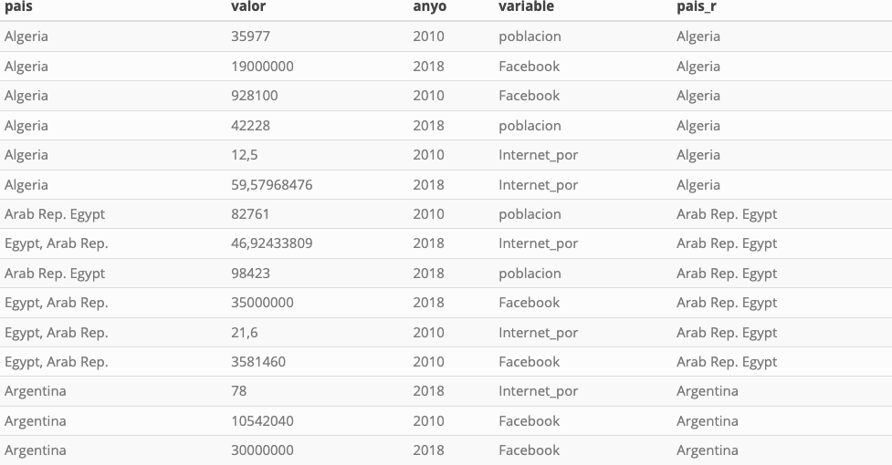

img-8

Utilizaremos un dataframe auxiliar y pivotaremos sobre la columna `variable` para lograr un conjunto de datos ordenado, en este proceso excluimos la columna original `pais` para evitar problemas de agrupación:

```r
# declaramos un nuevo dataframe donde excluimos la columna `pais` original y pivoteamos sobre la columna `variable`
df_wide <- df_aux %>%
    select(-pais) %>%
    pivot_wider(names_from = variable, values_from = valor)
```

Vemos nuevamente nuestro dataset:

[figure not shown]

img-9

Una vez se ha ordenado una tabla en observaciones y variables, el siguiente paso es mejorar la calidad del contenido de estas variables.

## Apartado 5 y Apartado 6

Necesitamos ahora crear 3 nuevas columnas limpiando y transformando las columnas antes generadas `Facebook`, `Internet_por` y `poblacion`. Primero utlizamos la funcion `glimpse()` para ver el estado actual de nuestro dataframe:

```r
# visualizamos nuestro dataframe
glimpse(df_wide)
```

```
## Rows: 156
## Columns: 5
## $ anyo         <chr> "2010", "2018", "2010", "2010", "2010", "2010", "2018", "…
## $ pais_r       <chr> "Ukraine", "Kuwait", "Iraq", "Hong Kong SAR, China", "Ire…
## $ Internet_por <chr> "23,3", "99,59999254", "2,5", "72", "69,85", "74,1", "93"…
## $ Facebook     <chr> "425680", "3100000", "225600", "3408240", "1597000", "227…
## $ poblacion    <chr> "  45870  ", "  4137  ", "  29741  ", "  7024  ", "  4560…
```

Como vemos las variables `Facebook`, `Internet_por` y `poblacion` son actualmente de tipo `character` (chr), analicemos entonces cada columna para saber que trabajos son necesarios:

#### Facebook

Crearemos una función `checkear_numeric` que devuelve TRUE o FALSE dependiendo de si el valor analizado puede o no ser casteado a numeric:

```r
# declaramos la función de checkeo
checkear_numeric <- function(val) {
  # intentamos convertir a numeric
  numeric <- suppressWarnings(as.numeric(val))

  # devolvemos T o F
  return(is.na(numeric))
}
```

Buscamos si existen valores que no podrán ser casteados a `numeric` para la variable `Facebook`, para ello utilizaremos una columna auxiliar que nos indicará si el valor tomado es o no problemático:

```r
# creamos una nueva columna con posibles casos problematicos
df_wide$facebook_prob <- sapply(df_wide$Facebook, checkear_numeric)

# checkeamos los casos problematicos
df_wide %>% filter(facebook_prob == T)
```

```
## # A tibble: 0 × 6
## # ℹ 6 variables: anyo <chr>, pais_r <chr>, Internet_por <chr>, Facebook <chr>,
## #   poblacion <chr>, facebook_prob <lgl>
```

Podemos ver que no existen campos problematicos para la variable `Facebook`, podemos proceder con la conversión de tipo de dato

```r
# creamos una nueva columna `facebook_num` con valores tipo numeric
df_wide <- df_wide %>% mutate(
    facebook_num = as.numeric(Facebook)
)
```

#### Poblacion

Hacemos el mismo análisis para la variable `poblacion`

```r
# creamos una nueva columna con posibles casos problematicos
df_wide$poblacion_prob <- sapply(df_wide$poblacion, checkear_numeric)

# checkeamos los casos problematicos
df_wide %>% filter(poblacion_prob == T)
```

```
## # A tibble: 2 × 8
##   anyo  pais_r Internet_por Facebook poblacion       facebook_prob facebook_num
##   <chr> <chr>  <chr>        <chr>    <chr>           <lgl>                <dbl>
## 1 2010  Taiwan <NA>         6745160  "  23.140,95  " FALSE              6745160
## 2 2018  Taiwan 88           18000000 "  23.580,08  " FALSE             18000000
## # ℹ 1 more variable: poblacion_prob <lgl>
```

En este caso podemos observar que dos valores tendrán problemas de casteo si fuesemos a convertirlos de manera directa:

- 23.140,95
- 23.580,08

Observamos que el problema de casteo viene dado por como están representados los numeros, es decir, estos dos valores problemáticos utilizan el caracter `.` como separador de miles mientras que el caracter `,` como separador decimal. Ambos valores debería ser:

- 23140.95
- 23580.08

Respectivamente, para poder ser casteables a numeric sin problemas.

Crearemos una función `limpiar_numeric` para eliminar el caracter `.` (punto) y luego reemplazar `,` (coma) por `.`, quedando un valor tipo `char` casteable a numeric.

```r
# declaramos la funcion
limpiar_numeric <- function(x) {
    # eliminamos puntos
    gsub("\\.", "", x) %>%
    # reemplazamos coma por punto
    gsub(",", ".", .)
}

# aplicamos la funcion limpiar a todos los valores del campo poblacion
df_wide$poblacion_r <- sapply(df_wide$poblacion, limpiar_numeric)
```

Volvemos a checkear posibles casos problematicos

```r
# OJO: reutilizamos columna de control
df_wide$poblacion_prob <- sapply(df_wide$poblacion_r, checkear_numeric)

# checkeamos los casos problematicos
df_wide %>% select(pais_r, anyo, poblacion, poblacion_prob, poblacion_r) %>% filter(poblacion_prob == T)
```

```
## # A tibble: 0 × 5
## # ℹ 5 variables: pais_r <chr>, anyo <chr>, poblacion <chr>,
## #   poblacion_prob <lgl>, poblacion_r <chr>
```

Habiendo corregido los posibles casos problematicos para la variable `poblacion` en una nueva columna llamada `poblacion_r`, procedemos a crear nuestra nueva columna de tipo de dato numerico con datos sanitizados:

```r
# creamos una nueva columna `poblacion_num` con valores tipo numeric
df_wide <- df_wide %>% mutate(
    poblacion_num = as.numeric(poblacion_r)
)
```

Además durante el ejercicio notamos que los numeros son demasiado pequeños para representar poblaciones de paises, habiando tomado como puntos de control Estados Unidos (United States) y España (Spain) vemos:

```r
df_wide %>% select(pais_r, anyo, poblacion_num) %>% filter(pais_r %in% c('Spain', 'United States'))
```

```
## # A tibble: 4 × 3
##   pais_r        anyo  poblacion_num
##   <chr>         <chr>         <dbl>
## 1 United States 2010         309326
## 2 Spain         2018          46723
## 3 Spain         2010          46576
## 4 United States 2018         327167
```

Haciendo una pequeña investigación nos damos cuenta que a los valores obtenidos de `poblacion_num` necesitamos multiplicarlos por 1000 para que coincidan con los registros públicos para ambos paises en ambos años. Suponemos el dato original `201X|poblacion` estaba expresado en miles de personas.

Controlamos lo datos para Estados Unidos y España:

```r
df_wide %>% select(pais_r, anyo, poblacion_num) %>% filter(pais_r %in% c('Spain', 'United States'))
```

[output not shown]

```r
# corregimos los valores para la variable poblacion_num
df_wide <- df_wide %>% mutate(
    poblacion_num = poblacion_num * 1000
)
```

#### Internet_por

Ahora haremos el mismo análisis para la variable `Internet_por`:

```r
# creamos una nueva columna con posibles casos problematicos
df_wide$internet_prob <- sapply(df_wide$Internet_por, checkear_numeric)

# checkeamos los casos problematicos
df_wide %>% select(pais_r, anyo, Internet_por, internet_prob) %>% filter(internet_prob == T)
```

```
## # A tibble: 116 × 4
##    pais_r          anyo  Internet_por internet_prob
##    <chr>           <chr> <chr>        <lgl>
##  1 Ukraine         2010  23,3         TRUE
##  2 Kuwait          2018  99,59999254  TRUE
##  3 Iraq            2010  2,5          TRUE
##  4 Ireland         2010  69,85        TRUE
##  5 Estonia         2010  74,1         TRUE
##  6 United States   2010  71,69        TRUE
##  7 Switzerland     2010  83,9         TRUE
##  8 Arab Rep. Egypt 2010  21,6         TRUE
##  9 Vietnam         2010  30,65        TRUE
## 10 Rwanda          2018  46,8         TRUE
## # ℹ 106 more rows
```

Vemos que en éste caso los valores problemáticos son 116, vamos a sanitizarlos

```r
# aplicamos la funcion limpiar a todos los valores del campo poblacion
df_wide$internet_r <- sapply(df_wide$Internet_por, limpiar_numeric)
```

```r
# OJO: reutilizamos columna de control
df_wide$internet_prob <- sapply(df_wide$internet_r, checkear_numeric)

# checkeamos los casos problematicos
df_wide %>% select(pais_r, anyo, Internet_por, internet_prob, internet_r) %>% filter(internet_prob == T)
```

```
## # A tibble: 1 × 5
##   pais_r anyo  Internet_por internet_prob internet_r
##   <chr>  <chr> <chr>        <lgl>         <chr>
## 1 Taiwan 2010  <NA>         TRUE          <NA>
```

```r
# corregimos el valor mencionado
df_wide <- df_wide %>%
  mutate(internet_r = ifelse(pais_r == 'Taiwan' & anyo == '2010', 1, internet_r))

# vemos nuevamente el dataframe y el dato manipulado
df_wide %>% select(pais_r, anyo, Internet_por, internet_prob, internet_r) %>% filter(internet_prob == T)
```

```
## # A tibble: 1 × 5
##   pais_r anyo  Internet_por internet_prob internet_r
##   <chr>  <chr> <chr>        <lgl>         <chr>
## 1 Taiwan 2010  <NA>         TRUE          1
```

Habiendo corregido los posibles casos problematicos para la variable `Internet_por` en una nueva columna llamada `internet_r`, procedemos a crear nuestra nueva columna de tipo de dato numerico con datos sanitizados:

```r
# creamos una nueva columna `internet_por_num` con valores tipo numeric
df_wide <- df_wide %>% mutate(
    internet_por_num = as.numeric(internet_r)
)
```

Vemos el resultado de nuestra manipulación para el pais **Taiwan** y el año **2010**:

```r
# seleccionamos los registros del pais `Taiwan`
df_wide %>% select(pais_r, anyo, facebook_num, poblacion_num, internet_por_num) %>% filter(pais_r == 'Taiwan')
```

```
## # A tibble: 2 × 5
##   pais_r anyo  facebook_num poblacion_num internet_por_num
##   <chr>  <chr>        <dbl>         <dbl>            <dbl>
## 1 Taiwan 2010       6745160      23140950                1
## 2 Taiwan 2018      18000000      23580080               88
```

Imprimimos nuestro dataset sanitizado, transformado y ordenado

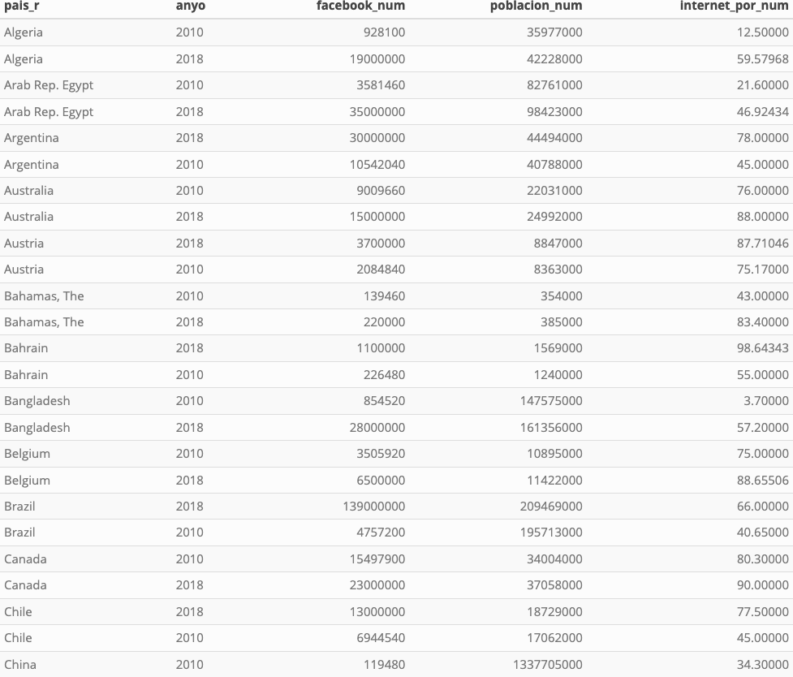

img-10

## Apartado 7

Para determinar el nivel de penetración de Facebook en España (Spain) debemos mirar que valores tomó nuesto grupo objetivo durante el tiempo:

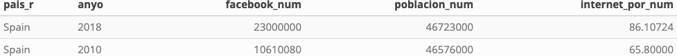

img-11

Tenemos que saber que segmento del total de población es **usuaria de internet** para luego establecer de ese conjunto objetivo, cuantos son usuarios de Facebook. Ya que para calcular el nivel de penetración del producto solo **consideramos posibles usuarios a toda aquella persona que tenga acceso a internet**.

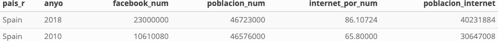

img-12

```r
# creamos dos nuevas variables para ayudar a nuestro análisis
df_wide <- df_wide %>% mutate(
    poblacion_internet = poblacion_num * internet_por_num / 100,
    poblacion_internet_facebook = facebook_num * 100 / (poblacion_num * internet_por_num / 100)
)

# creamos la imagen
kable(df_wide %>% select(pais_r, anyo, facebook_num, poblacion_num, internet_por_num, poblacion_internet) %>% filter(pais_r == 'Spain'), "html", booktabs=TRUE) %>%
    kable_styling(bootstrap_options=c("striped", "hover", "condensed", "responsive")
    ,font_size = 15,full_width = T) %>%
    save_kable("temp/spain_new.png")
```

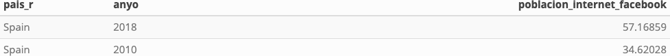

img-13

```r
kable(df_wide %>% select(pais_r, anyo, poblacion_internet_facebook) %>% filter(pais_r == 'Spain'), "html", booktabs=TRUE) %>%
    kable_styling(bootstrap_options=c("striped", "hover", "condensed", "responsive")
    ,font_size = 15,full_width = T) %>%
    save_kable("temp/spain_penetration.png")
```